# Assignment_5

```python
# Import necessary libraries
import numpy as np
import pandas as pd
import matplotlib.pyplot as plt
from sklearn import svm

# Read the data
data=pd.read_csv("HW5.csv")
```

a) Convert medication and test results columns to numbers

```python
## Ensure all medications are converted to numbers
data['Medication'].replace(['Paracetamol', 'Ibuprofen', 'Aspirin', 'Penicillin', 'Amoxicillin', 'Lipitor'],
                           [0, 1, 2, 3, 4, 5], inplace=True)

# Convert 'Test Results' column to numerical values
data['Test Results'].replace(['Normal', 'Inconclusive', 'Abnormal'],
                             [0, 1, 2], inplace=True)
```

b) X : [age, medication], y: [test results]

```python
x = data[['Age', 'Medication']].values
y = data['Test Results'].values
x = X[:1500, :]
y = y[:1500]
```

d) Find the accuracy. Which kernel classifies data better?

```python
# define- fit - predict - find the accuracy of models
from sklearn.metrics import accuracy_score
# linear kernel
svc=svm.SVC(kernel='linear', C=1).fit(x,y)
svc_pred=svc.predict(x)
print('svc accuracy',accuracy_score(y,svc_pred)*100)
# linear svm
lin_svc=svm.LinearSVC(C=1).fit(x,y)
lsvc_pred=lin_svc.predict(x)
print('linear svc accuracy',accuracy_score(y,lsvc_pred)*100)
# rbf kernel
rbf_svc=svm.SVC(kernel='rbf', gamma=0.7, C=1).fit(x,y)
rsvc_pred=rbf_svc.predict(x)
print('rbf accuracy',accuracy_score(y,rsvc_pred)*100)
# poly kernel, degree 3 ax^3+bx^2+cx+d
poly_svc=svm.SVC(kernel='poly', degree=3, C=1).fit(x,y)
psvc_pred=poly_svc.predict(x)
print('poly accuracy',accuracy_score(y,psvc_pred)*100)
```

```
svc accuracy 35.86666666666667
```

```
C:\Users\fazal\anaconda3\Anaconda 3 latest\Lib\site-packages\sklearn\svm\_classes.py:31: FutureWarning: The default value of `dual` will change from `True` to `'auto'` in 1.5. Set the value of `dual` explicitly to suppress the warning.
  warnings.warn(
C:\Users\fazal\anaconda3\Anaconda 3 latest\Lib\site-packages\sklearn\svm\_base.py:1237: ConvergenceWarning: Liblinear failed to converge, increase the number of iterations.
  warnings.warn(
```

```
linear svc accuracy 34.13333333333333
rbf accuracy 53.46666666666666
poly accuracy 35.86666666666667
```

Based on calculating the accuracy of 4 kernels, the RBF kernel classifies the data best, with an accuracy of 53.4%. Hence it is the best kernel that classifies data.

C) Make the graph of SVM with 4 kernels. e) Copy the graphs.

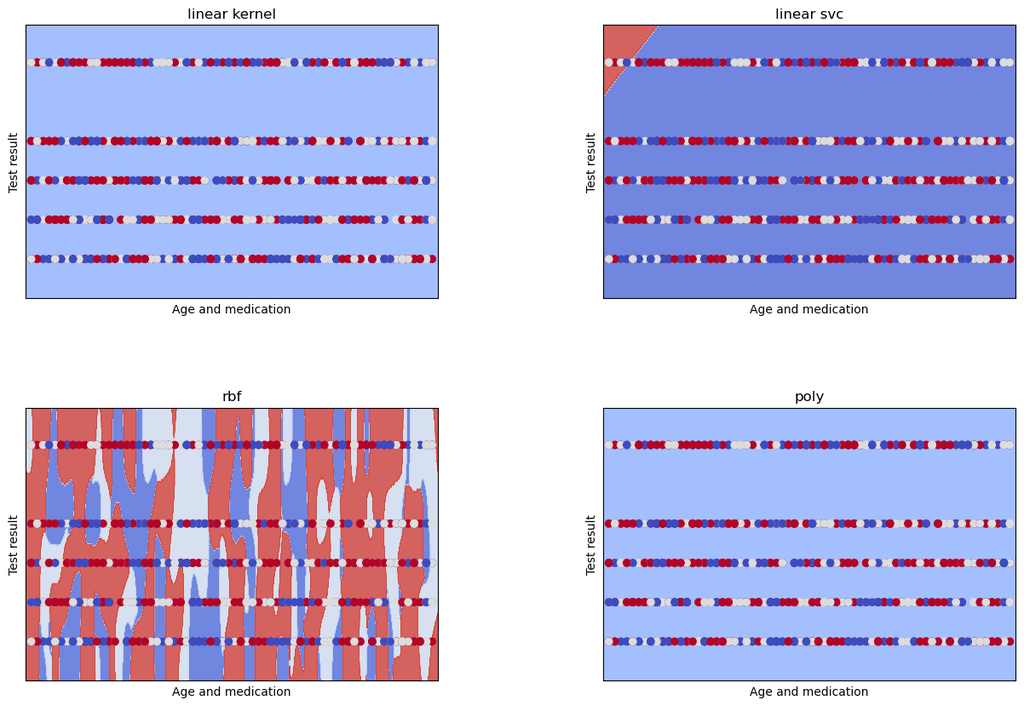

```python
h = 0.05
x_min, x_max = x[:, 0].min() - 1, x[:, 0].max() + 1  # Using NumPy array indexing
y_min, y_max = x[:, 1].min() - 1, x[:, 1].max() + 1
xx, yy = np.meshgrid(np.arange(x_min, x_max, h), np.arange(y_min, y_max, h))

# Create the plot
plt.figure(figsize=(15, 10))

titles = ['linear kernel', 'linear svc', 'rbf', 'poly']

for i, clf in enumerate((svc, lin_svc, rbf_svc, poly_svc)):
    # Create 4 subplots
    plt.subplot(2, 2, i + 1)
    plt.subplots_adjust(wspace=0.4, hspace=0.4)

    # Predict using the classifier
    Z = clf.predict(np.c_[xx.ravel(), yy.ravel()])
    Z = Z.reshape(xx.shape)

    # plot actual and predicted values
    plt.contourf(xx, yy, Z, cmap=plt.cm.coolwarm, alpha=0.8)
    plt.scatter(x[:, 0], x[:, 1], c=y, cmap=plt.cm.coolwarm)  # Using NumPy array indexing

    # Customize the plot
    plt.xlabel('Age and medication')
    plt.ylabel('Test result')
    plt.xlim(xx.min(), xx.max())
    plt.ylim(yy.min(), yy.max())
    plt.xticks(())
    plt.yticks(())
    plt.title(titles[i])

plt.show()
```

f) Interpret the graphs: Looking at these four models, the RBF shows the most realistic pattern by capturing complex relationships between age, medications, and test results - just like how in real medical cases, the interaction between patient age and drug response isn't always straightforward. The other three models seem too simplified for medical data, as they assume simple straight-line patterns. For healthcare predictions, we'd probably want to use the RBF model since it better reflects the complexity of real patient responses, even though it might look complex than the others. The striped pattern in the RBF plot suggests it's picking up on important variations in how different age groups respond to different medications.